# Supplementary Study

## (1) Description of Data Files

The posted data for this study consists of 1 compiled, deidentified data file (total *N* recruited = 122):

- 5 participants excluded because they did not identify as undergraduate students

## (2) Descriptive Statistics

**Total *N*:** 117

```
## gender
## female   male   <NA>
##     60     57      0
```

**Percentage by race:**

```
## race
##        white        asian        multi       latino        black asian indian         <NA>
##         55.6         23.9          8.5          5.1          4.3          1.7          0.9
```

```
## race.cat
## non-stigmatized     stigmatized            <NA>
##            81.2            17.9             0.9
```

**Percentage by college class:**

```
## class
##  freshman    junior    senior sophomore      <NA>
##      24.8      16.2       7.7      51.3       0.0
```

**Percentage by income:**

```
## income.label
##   (1) $25,000 or less   (2) $25,001-$40,000   (3) $40,001-$70,000   (4) $70,001-$90,000
##                   6.0                   1.7                  12.0                  11.1
## (6) $120,001-$150,000 (7) $150,001-$200,000 (8) $200,001-$300,000  (9) $300,001 or more
##                  21.4                  10.3                   6.8                  18.8
##                  <NA>
##                  12.0
```

*M*s and *SD*s:

```
##              n      mean        sd   min      max
## In.Age     117     19.75      0.94 18.00 2.30e+01
## ladder      99      7.11      2.01  1.00 1.00e+01
## psm         94      4.60      0.78  2.62 6.12e+00
## pwe         97      3.37      1.00  1.00 5.75e+00
## lti        117      3.63      1.14  1.00 6.00e+00
## income     103 190626.21 183878.61  0.00 1.00e+06
## income.cat 103      5.83      2.47  1.00 9.00e+00
## gpa         92      3.37      0.52  1.33 4.00e+00
```

**Alphas:**

- **Perceptions of socioeconomic mobility (psm):** 0.79
- **Protestant work ethic (pwe):** 0.74
- **Lay theories of intelligence (lti):** 0.8

**Correlations between income and subjective SES:**

```
##
##  Pearson's product-moment correlation
##
## data:  income and ladder
## t = 6.3022, df = 87, p-value = 1.17e-08
## alternative hypothesis: true correlation is not equal to 0
## 95 percent confidence interval:
##  0.3980025 0.6879061
## sample estimates:
##       cor
## 0.5598548
```

```
##
##  Pearson's product-moment correlation
##
## data:  income.cat and ladder
## t = 8.2206, df = 87, p-value = 1.761e-12
## alternative hypothesis: true correlation is not equal to 0
## 95 percent confidence interval:
##  0.5252666 0.7642200
## sample estimates:
##      cor
## 0.661195
```

**Correlation between perceptions of socioeconomic mobility and Protestant work ethic:**

```
##
##  Pearson's product-moment correlation
##
## data:  psm and pwe
## t = 2.5118, df = 92, p-value = 0.01375
## alternative hypothesis: true correlation is not equal to 0
## 95 percent confidence interval:
##  0.05345921 0.43368817
## sample estimates:
##       cor
## 0.2533322
```

**Correlation between perceptions of socioeconomic mobility and lay theories of intelligence:**

```
##
##  Pearson's product-moment correlation
##
## data:  psm and lti
## t = 0.38694, df = 92, p-value = 0.6997
## alternative hypothesis: true correlation is not equal to 0
## 95 percent confidence interval:
##  -0.1636451  0.2409574
## sample estimates:
##        cor
## 0.04030834
```

**Correlation between Protestant work ethic and lay theories of intelligence:**

```
##
##  Pearson's product-moment correlation
##
## data:  pwe and lti
## t = -1.232, df = 95, p-value = 0.221
## alternative hypothesis: true correlation is not equal to 0
## 95 percent confidence interval:
##  -0.31692537  0.07593777
## sample estimates:
##        cor
## -0.1254069
```

## (3) Main Analyses

### Analyses with income and without covariates

**Correlation with GPA**

```
##
##  Pearson's product-moment correlation
##
## data:  gpa and income.cat
## t = 1.1439, df = 79, p-value = 0.2561
## alternative hypothesis: true correlation is not equal to 0
## 95 percent confidence interval:
##  -0.09330603  0.33661162
## sample estimates:
##       cor
## 0.1276439
```

**Omnibus test:**

```
##
## Call:
## lm(formula = gpa ~ psm_c * incomecat_c)
##
## Residuals:
##      Min       1Q   Median       3Q      Max
## -2.11410 -0.16510  0.09538  0.33839  0.64648
##
## Coefficients:
##                   Estimate Standardized Std. Error t value Pr(>|t|)
## (Intercept)        3.41293      0.00000    0.05773  59.122   <2e-16 ***
## psm_c              0.08300      0.12672    0.07450   1.114    0.269
## incomecat_c        0.02307      0.11591    0.02267   1.018    0.312
## psm_c:incomecat_c -0.04623     -0.18736    0.02768  -1.671    0.099 .
## ---
## Signif. codes:  0 '***' 0.001 '**' 0.01 '*' 0.05 '.' 0.1 ' ' 1
##
## Residual standard error: 0.5003 on 74 degrees of freedom
##   (39 observations deleted due to missingness)
## Multiple R-squared:  0.07201,    Adjusted R-squared:  0.03439
## F-statistic: 1.914 on 3 and 74 DF,  p-value: 0.1347
```

**95% confidence intervals for unstandardized regression coefficients:**

```
##                   Lower (estimate) Upper (estimate)
## (Intercept)                   3.30             3.53
## psm_c                        -0.07             0.23
## incomecat_c                  -0.02             0.07
## psm_c:incomecat_c            -0.10             0.01
```

**Simple slopes tests:**

```
##
## ** Estimated points of gpa  **
##
##                          Low psm_c (-1 SD) High psm_c (+1 SD)
## Low incomecat_c (-1 SD)             3.2008             3.5000
## High incomecat_c (+1 SD)            3.5124             3.4439
##
##
##
## ** Simple Slopes analysis ( df= 74 ) **
##
##                          simple slope standard error t-value p.value
## Low incomecat_c (-1 SD)        0.1925         0.0998    1.93   0.058 .
## High incomecat_c (+1 SD)      -0.0441         0.1059   -0.42   0.678
## ---
## Signif. codes:  0 '***' 0.001 '**' 0.01 '*' 0.05 '.' 0.1 ' ' 1
##
##
##
## ** Bauer & Curran 95% CI **
##
##             lower CI upper CI
## incomecat_c  -6.5883  -2.7212
```

**CIs for low-income students:** -0.01, 0.39

**CIs for high-income students:** -0.26, 0.17

**Plot:**

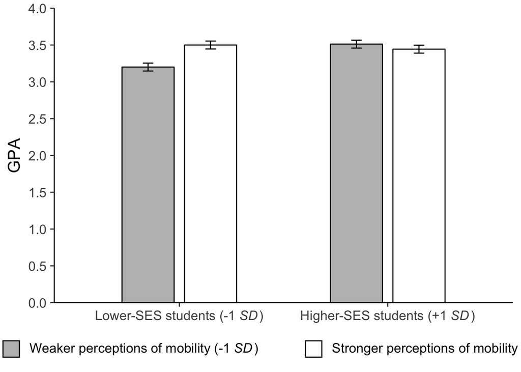

### Analyses with subjective SES and without covariates

**Correlation with GPA**

```
##
##  Pearson's product-moment correlation
##
## data:  gpa and ladder
## t = 2.3757, df = 88, p-value = 0.01969
## alternative hypothesis: true correlation is not equal to 0
## 95 percent confidence interval:
##  0.04046166 0.43069052
## sample estimates:
##       cor
## 0.2454957
```

**Omnibus test:**

```
##
## Call:
## lm(formula = gpa ~ psm_c * ladder_c)
##
## Residuals:
##      Min       1Q   Median       3Q      Max
## -2.13052 -0.17450  0.09943  0.30556  0.94887
##
## Coefficients:
##                Estimate Standardized Std. Error t value Pr(>|t|)
## (Intercept)     3.42127      0.00000    0.05270  64.917  < 2e-16 ***
## psm_c           0.07703      0.11839    0.06707   1.149  0.25401
## ladder_c        0.05568      0.21254    0.02700   2.063  0.04225 *
## psm_c:ladder_c -0.10688     -0.29525    0.03626  -2.947  0.00415 **
## ---
## Signif. codes:  0 '***' 0.001 '**' 0.01 '*' 0.05 '.' 0.1 ' ' 1
##
## Residual standard error: 0.4776 on 84 degrees of freedom
##   (29 observations deleted due to missingness)
## Multiple R-squared:  0.1591, Adjusted R-squared:  0.129
## F-statistic: 5.296 on 3 and 84 DF,  p-value: 0.002154
```

**95% confidence intervals for unstandardized regression coefficients:**

```
##                Lower (estimate) Upper (estimate)
## (Intercept)                3.32             3.53
## psm_c                     -0.06             0.21
## ladder_c                   0.00             0.11
## psm_c:ladder_c            -0.18            -0.03
```

**Simple slopes tests:**

```
##
## ** Estimated points of gpa  **
##
##                       Low psm_c (-1 SD) High psm_c (+1 SD)
## Low ladder_c (-1 SD)             3.1092             3.5374
## High ladder_c (+1 SD)            3.6495             3.4208
##
##
##
## ** Simple Slopes analysis ( df= 84 ) **
##
##                       simple slope standard error t-value p.value
## Low ladder_c (-1 SD)        0.2722         0.0962    2.83  0.0058 **
## High ladder_c (+1 SD)      -0.1454         0.0988   -1.47  0.1451
## ---
## Signif. codes:  0 '***' 0.001 '**' 0.01 '*' 0.05 '.' 0.1 ' ' 1
##
##
##
## ** Bauer & Curran 95% CI **
##
##          lower CI upper CI
## ladder_c  -0.5845   3.0465
```

**CIs for low subjective SES students:** 0.08, 0.46

**CIs for high subjective SES students:** -0.34, 0.05

### Analyses with income and covariates

**Omnibus test:**

```
##
## Call:
## lm(formula = gpa ~ psm_c * incomecat_c + pwe_c * incomecat_c +
##     lti_c * incomecat_c)
##
## Residuals:
##      Min       1Q   Median       3Q      Max
## -2.09581 -0.18845  0.06946  0.28240  0.75321
##
## Coefficients:
##                     Estimate Standardized Std. Error t value Pr(>|t|)
## (Intercept)        3.4393343    0.0000000  0.0594246  57.877   <2e-16 ***
## psm_c              0.1212671    0.1851493  0.0775933   1.563   0.1226
## incomecat_c        0.0128596    0.0646219  0.0239843   0.536   0.5935
## pwe_c             -0.1049856   -0.2019066  0.0624322  -1.682   0.0971 .
## lti_c             -0.0308590   -0.0642553  0.0555945  -0.555   0.5806
## psm_c:incomecat_c -0.0481901   -0.1952884  0.0283411  -1.700   0.0935 .
## incomecat_c:pwe_c  0.0003957    0.0019936  0.0234269   0.017   0.9866
## incomecat_c:lti_c  0.0300967    0.1580491  0.0222773   1.351   0.1810
## ---
## Signif. codes:  0 '***' 0.001 '**' 0.01 '*' 0.05 '.' 0.1 ' ' 1
##
## Residual standard error: 0.497 on 70 degrees of freedom
##   (39 observations deleted due to missingness)
## Multiple R-squared:  0.1337, Adjusted R-squared:  0.04703
## F-statistic: 1.543 on 7 and 70 DF,  p-value: 0.1673
```

**95% confidence intervals for unstandardized regression coefficients:**

```
##                   Lower (estimate) Upper (estimate)
## (Intercept)                   3.32             3.56
## psm_c                        -0.03             0.28
## incomecat_c                  -0.03             0.06
## pwe_c                        -0.23             0.02
## lti_c                        -0.14             0.08
## psm_c:incomecat_c            -0.10             0.01
## incomecat_c:pwe_c            -0.05             0.05
## incomecat_c:lti_c            -0.01             0.07
```

**Simple slopes tests:**

```
##
## ** Estimated points of gpa  **
##
##                          Low psm_c (-1 SD) High psm_c (+1 SD)
## Low incomecat_c (-1 SD)             3.2163             3.5822
## High incomecat_c (+1 SD)            3.4839             3.4664
##
##
##
## ** Simple Slopes analysis ( df= 70 ) **
##
##                          simple slope standard error t-value p.value
## Low incomecat_c (-1 SD)        0.2354         0.1058    2.22   0.029 *
## High incomecat_c (+1 SD)      -0.0112         0.1064   -0.11   0.916
## ---
## Signif. codes:  0 '***' 0.001 '**' 0.01 '*' 0.05 '.' 0.1 ' ' 1
##
##
##
## ** Bauer & Curran 95% CI **
##
##             lower CI upper CI
## incomecat_c  -13.043  -0.8461
```

**CIs for low-income students:** 0.02, 0.45

**CIs for high-income students:** -0.22, 0.2

### Analyses with subjective SES and covariates

**Omnibus test:**

```
##
## Call:
## lm(formula = gpa ~ psm_c * ladder_c + pwe_c * ladder_c + lti_c *
##     ladder_c)
##
## Residuals:
##      Min       1Q   Median       3Q      Max
## -2.12297 -0.20696  0.06477  0.29334  0.94987
##
## Coefficients:
##                Estimate Standardized Std. Error t value Pr(>|t|)
## (Intercept)     3.42809      0.00000    0.05366  63.881  < 2e-16 ***
## psm_c           0.10025      0.15409    0.07174   1.397  0.16614
## ladder_c        0.04682      0.17871    0.02991   1.566  0.12140
## pwe_c          -0.05350     -0.10253    0.05770  -0.927  0.35661
## lti_c          -0.04385     -0.09443    0.04793  -0.915  0.36296
## psm_c:ladder_c -0.10240     -0.28289    0.03749  -2.732  0.00775 **
## ladder_c:pwe_c -0.01051     -0.04285    0.02645  -0.397  0.69225
## ladder_c:lti_c  0.01676      0.06854    0.02694   0.622  0.53557
## ---
## Signif. codes:  0 '***' 0.001 '**' 0.01 '*' 0.05 '.' 0.1 ' ' 1
##
## Residual standard error: 0.4824 on 80 degrees of freedom
##   (29 observations deleted due to missingness)
## Multiple R-squared:  0.1832, Adjusted R-squared:  0.1117
## F-statistic: 2.562 on 7 and 80 DF,  p-value: 0.0196
```

**95% confidence intervals for unstandardized regression coefficients:**

```
##                Lower (estimate) Upper (estimate)
## (Intercept)                3.32             3.53
## psm_c                     -0.04             0.24
## ladder_c                  -0.01             0.11
## pwe_c                     -0.17             0.06
## lti_c                     -0.14             0.05
## psm_c:ladder_c            -0.18            -0.03
## ladder_c:pwe_c            -0.06             0.04
## ladder_c:lti_c            -0.04             0.07
```

**Simple slopes tests:**

```
##
## ** Estimated points of gpa  **
##
##                       Low psm_c (-1 SD) High psm_c (+1 SD)
## Low ladder_c (-1 SD)             3.1206             3.5725
## High ladder_c (+1 SD)            3.6127             3.4352
##
##
##
## ** Simple Slopes analysis ( df= 80 ) **
##
##                       simple slope standard error t-value p.value
## Low ladder_c (-1 SD)         0.287          0.102    2.82   0.006 **
## High ladder_c (+1 SD)       -0.113          0.103   -1.09   0.277
## ---
## Signif. codes:  0 '***' 0.001 '**' 0.01 '*' 0.05 '.' 0.1 ' ' 1
##
##
##
## ** Bauer & Curran 95% CI **
##
##          lower CI upper CI
## ladder_c  -0.4475   4.2697
```

**CIs for low subjective SES students:** 0.08, 0.49

**CIs for high subjective SES students:** -0.32, 0.09